# PART-1

1. A. The joint probability of the people who planned to purchase and actually placed an order:(400/2000)/(500/2000) = 0.8;

   B. The joint probability of the people who planned to purchase and actually placed an order, given that people planned to purchase: (500/2000) = 0.25
2. The question addresses Binomial distribution B(x)= n!/{x!.(n-x)!}.(p^x).(1-p)^n-x 0.05 : is the probability of being defect 1-0.05 = 0.95 : is the probability of being not defect; A. B(0) = (10!/10!)x(0.05)^0x(0.95)^10 = 1x1x0.598736; B(0)=0.598

   B. B(1) = (10!/1!.9!)x(0.05)^1x(0.95)^9 = 10x0.05x0.630 = 0.315

   C. two or fewer means B(2)+ B(1) +B(0) = 0.598+0.315+0.07463 =0.98763

   D. three or more means = B(3)+B(4)+B(5)+B(6)+B(7)+B(8)+B(9)+B(10); = 0.01 + 0.000964 + 0.00006092 + 0.0000017094 + 0 + 0 + 0 + 0; = 0.01102
3. m=3 A. Some cars means (1 or more cars); P(x>0)=1-p(x0) p(x=x0) = (3^0e^-3)/0! = 0.049787 p(x>1)(x=1) = 0.95021

   B. The probability of selling two or more but less than five cars p(2<x<3)= (3^2xe^-3)/2! + (3^3xe^-3)/3! + (3^4xe^-3)/4!

   ```
       = 0.61611
   ```

   C. 3/5=0.6' P(x) = {e-(0.6)x(0.6)^1}/1! = 0.32929
4. 86.8 i.e. 0.86 (correctly), 0.132 (not correctly)

   A. 0.86^3 = 0.653

   B. 0.132^3 = 0.002

   C. 3!/(2!x1!)x(0.86)^2 x(0.132)^1 = 3x0.73x0.13 = 0.287

   3!/(3!x0!)x (0.86)^3 x (0.132)^0 = 1x0.63x1 = 0.63
5. P = 300; Mean (X) = 60; SD = 12 X1=80;X2=50 Z1 =(x1-x)/SD = (80-60)/12 = 1.66 Z2 =(x2-x)/SD = (50-60)/12 = -0.833

   from Z-table A1= 0.04947 A2= 0.2023

   A. The percentage of students who score more than 80 = 300*0.04947 = 14.841%

   B. The percentage of students who score less than 50 = 300*0.2023 = 60.7%

   C. The distinction mark for the highest 10% of students is =60+12(0.42465) =65.0958
1. Goal : To launch new tasty tomato varities in the market. Scientists have collected taste data from 300 tomato varieties. About, 20% of these tomato varities reached final stage. What is the probability that atleast 45 of the 300 varities will be registered ?

   S.D.(u) = 300(.2) = 60; The standard deviation is Sqrt(300X0.2X0.8)= Sqrt48 = 6.92.

# PART-2

```python
import numpy as np
import pandas as pd
import seaborn as sns
import matplotlib.pyplot as plt
sns.set(color_codes=True)
%matplotlib inline
```

```python
Sports = pd.read_csv('Basketball.csv')
```

```python
Sports.head()
```

|  | Team | Tournament | Score | PlayedGames | WonGames | DrawnGames | LostGames | BasketScored | BasketGiven | TournamentChampion | Runner-up | TeamLaunch | HighestPositionHeld |
| --- | --- | --- | --- | --- | --- | --- | --- | --- | --- | --- | --- | --- | --- |
| 0 | Team 1 | 86 | 4385 | 2762 | 1647 | 552 | 563 | 5947 | 3140 | 33 | 23 | 1929 | 1 |
| 1 | Team 2 | 86 | 4262 | 2762 | 1581 | 573 | 608 | 5900 | 3114 | 25 | 25 | 1929 | 1 |
| 2 | Team 3 | 80 | 3442 | 2614 | 1241 | 598 | 775 | 4534 | 3309 | 10 | 8 | 1929 | 1 |
| 3 | Team 4 | 82 | 3386 | 2664 | 1187 | 616 | 861 | 4398 | 3469 | 6 | 6 | 1931 | 1 |
| 4 | Team 5 | 86 | 3368 | 2762 | 1209 | 633 | 920 | 4631 | 3700 | 8 | 7 | 1929 | 1 |

```python
Sports.head(8)
```

|  | Team | Tournament | Score | PlayedGames | WonGames | DrawnGames | LostGames | BasketScored | BasketGiven | TournamentChampion | Runner-up | TeamLaunch | HighestPositionHeld |
| --- | --- | --- | --- | --- | --- | --- | --- | --- | --- | --- | --- | --- | --- |
| 0 | Team 1 | 86 | 4385 | 2762 | 1647 | 552 | 563 | 5947 | 3140 | 33 | 23 | 1929 | 1 |
| 1 | Team 2 | 86 | 4262 | 2762 | 1581 | 573 | 608 | 5900 | 3114 | 25 | 25 | 1929 | 1 |
| 2 | Team 3 | 80 | 3442 | 2614 | 1241 | 598 | 775 | 4534 | 3309 | 10 | 8 | 1929 | 1 |
| 3 | Team 4 | 82 | 3386 | 2664 | 1187 | 616 | 861 | 4398 | 3469 | 6 | 6 | 1931 | 1 |
| 4 | Team 5 | 86 | 3368 | 2762 | 1209 | 633 | 920 | 4631 | 3700 | 8 | 7 | 1929 | 1 |
| 5 | Team 6 | 73 | 2819 | 2408 | 990 | 531 | 887 | 3680 | 3373 | 1 | 4 | 1934 | 1 |
| 6 | Team 7 | 82 | 2792 | 2626 | 948 | 608 | 1070 | 3609 | 3889 | - | - | 1929 | 3 |
| 7 | Team 8 | 70 | 2573 | 2302 | 864 | 577 | 861 | 3228 | 3230 | 2 | 3 | 1929 | 1 |

```python
Sports.tail(10)
```

|  | Team | Tournament | Score | PlayedGames | WonGames | DrawnGames | LostGames | BasketScored | BasketGiven | TournamentChampion | Runner-up | TeamLaunch | HighestPositionHeld |
| --- | --- | --- | --- | --- | --- | --- | --- | --- | --- | --- | --- | --- | --- |
| 51 | Team 52 | 4 | 56 | 72 | 21 | 14 | 37 | 153 | 184 | - | - | 1929 | 6 |
| 52 | Team 53 | 2 | 52 | 68 | 17 | 18 | 33 | 71 | 116 | - | - | 1979 | 10 |
| 53 | Team 54 | 3 | 42 | 54 | 18 | 6 | 30 | 97 | 131 | - | - | 1929 | 8 |
| 54 | Team 55 | 2 | 40 | 68 | 13 | 14 | 41 | 70 | 182 | - | - | 1950 | 16 |
| 55 | Team 56 | 1 | 35 | 38 | 8 | 11 | 19 | 36 | 55 | - | - | 2016 | 17 |
| 56 | Team 57 | 1 | 34 | 38 | 8 | 10 | 20 | 38 | 66 | - | - | 2009 | 20 |
| 57 | Team 58 | 1 | 22 | 30 | 7 | 8 | 15 | 37 | 57 | - | - | 1956 | 16 |
| 58 | Team 59 | 1 | 19 | 30 | 7 | 5 | 18 | 51 | 85 | - | - | 1951 | 16 |
| 59 | Team 60 | 1 | 14 | 30 | 5 | 4 | 21 | 34 | 65 | - | - | 1955 | 15 |
| 60 | Team 61 | 1 | - | - | - | - | - | - | - | - | - | 2017 | 9 |

```python
print(Sports.shape)
print (Sports.size)
```

```
(61, 13)
793
```

```python
df.info()
```

```
<class 'pandas.core.frame.DataFrame'>
RangeIndex: 61 entries, 0 to 60
Data columns (total 13 columns):
 #   Column               Non-Null Count  Dtype
---  ------               --------------  -----
 0   Team                 61 non-null     object
 1   Tournament           61 non-null     int64
 2   Score                61 non-null     object
 3   PlayedGames          61 non-null     object
 4   WonGames             61 non-null     object
 5   DrawnGames           61 non-null     object
 6   LostGames            61 non-null     object
 7   BasketScored         61 non-null     object
 8   BasketGiven          61 non-null     object
 9   TournamentChampion   61 non-null     object
 10  Runner-up            60 non-null     object
 11  TeamLaunch           61 non-null     int64
 12  HighestPositionHeld  61 non-null     int64
dtypes: int64(3), object(10)
memory usage: 6.3+ KB
```

```python
Sports.count()
```

```
Team                   61
Tournament             61
Score                  61
PlayedGames            61
WonGames               61
DrawnGames             61
LostGames              61
BasketScored           61
BasketGiven            61
TournamentChampion     61
Runner-up              60
TeamLaunch             61
HighestPositionHeld    61
dtype: int64
```

```python
Sports.isnull().sum()
```

```
Team                   0
Tournament             0
Score                  0
PlayedGames            0
WonGames               0
DrawnGames             0
LostGames              0
BasketScored           0
BasketGiven            0
TournamentChampion     0
Runner-up              1
TeamLaunch             0
HighestPositionHeld    0
dtype: int64
```

```python
Sports.isnull().any().any()
```

```
True
```

```python
null_cols = Sports.columns[Sports.isnull().any()]
null_cols = list(null_cols)
```

```python
Sports.isnull().sum()
```

```
Team                   0
Tournament             0
Score                  0
PlayedGames            0
WonGames               0
DrawnGames             0
LostGames              0
BasketScored           0
BasketGiven            0
TournamentChampion     0
Runner-up              1
TeamLaunch             0
HighestPositionHeld    0
dtype: int64
```

```python
df[df['Runner-up'].isnull()]
```

|  | Team | Tournament | Score | PlayedGames | WonGames | DrawnGames | LostGames | BasketScored | BasketGiven | TournamentChampion | Runner-up | TeamLaunch | HighestPositionHeld |
| --- | --- | --- | --- | --- | --- | --- | --- | --- | --- | --- | --- | --- | --- |
| 9 | Team 10 | 51 | 1884 | 1728 | 606 | 440 | 682 | 2159 | 2492 | 1 | NaN | 1932 | 1 |

```python
df['Runner-up'].count()
```

```
60
```

```python
#pd.Index([1, 2, 3])
```

```python
df.Score.max()
df.Score.sort_values(ascending = False).head(20)
df[df.Score ==df.Score.max()]
df.sort_values(by = 'Score', ascending = False).head(20)
```

|  | Team | Tournament | Score | PlayedGames | WonGames | DrawnGames | LostGames | BasketScored | BasketGiven | TournamentChampion | Runner-up | TeamLaunch | HighestPositionHeld |
| --- | --- | --- | --- | --- | --- | --- | --- | --- | --- | --- | --- | --- | --- |
| 20 | Team 21 | 17 | 970 | 646 | 266 | 172 | 208 | 892 | 789 | - | 1 | 1998 | 2 |
| 45 | Team 46 | 3 | 96 | 114 | 26 | 44 | 44 | 101 | 139 | - | - | 1990 | 9 |
| 46 | Team 47 | 4 | 91 | 116 | 34 | 16 | 66 | 181 | 295 | - | - | 1947 | 7 |
| 47 | Team 48 | 2 | 83 | 80 | 20 | 23 | 37 | 62 | 117 | - | - | 1996 | 17 |
| 48 | Team 49 | 2 | 81 | 80 | 19 | 24 | 37 | 70 | 115 | - | - | 1995 | 19 |
| 49 | Team 50 | 4 | 76 | 108 | 30 | 16 | 62 | 145 | 252 | - | - | 1945 | 10 |
| 50 | Team 51 | 3 | 71 | 90 | 29 | 13 | 48 | 121 | 183 | - | - | 1953 | 14 |
| 21 | Team 22 | 23 | 667 | 742 | 218 | 175 | 349 | 819 | 1157 | - | - | 1941 | 6 |
| 22 | Team 23 | 17 | 662 | 652 | 189 | 148 | 305 | 760 | 1088 | - | - | 1977 | 8 |
| 23 | Team 24 | 21 | 606 | 678 | 203 | 180 | 295 | 750 | 1022 | - | - | 1959 | 5 |
| 51 | Team 52 | 4 | 56 | 72 | 21 | 14 | 37 | 153 | 184 | - | - | 1929 | 6 |
| 24 | Team 25 | 12 | 553 | 456 | 147 | 112 | 197 | 520 | 633 | - | - | 2004 | 6 |
| 25 | Team 26 | 20 | 538 | 628 | 184 | 149 | 295 | 716 | 1050 | - | - | 1935 | 5 |
| 52 | Team 53 | 2 | 52 | 68 | 17 | 18 | 33 | 71 | 116 | - | - | 1979 | 10 |
| 26 | Team 27 | 13 | 510 | 494 | 155 | 128 | 211 | 619 | 744 | - | - | 1961 | 5 |
| 27 | Team 28 | 18 | 445 | 586 | 145 | 143 | 298 | 607 | 992 | - | - | 1940 | 11 |
| 0 | Team 1 | 86 | 4385 | 2762 | 1647 | 552 | 563 | 5947 | 3140 | 33 | 23 | 1929 | 1 |
| 1 | Team 2 | 86 | 4262 | 2762 | 1581 | 573 | 608 | 5900 | 3114 | 25 | 25 | 1929 | 1 |
| 28 | Team 29 | 12 | 421 | 380 | 125 | 81 | 174 | 458 | 623 | - | - | 1930 | 6 |
| 53 | Team 54 | 3 | 42 | 54 | 18 | 6 | 30 | 97 | 131 | - | - | 1929 | 8 |

```python
len(df)
```

```
61
```

```python
df.dtypes
```

```
Team                   object
Tournament              int64
Score                  object
PlayedGames            object
WonGames               object
DrawnGames             object
LostGames              object
BasketScored           object
BasketGiven            object
TournamentChampion     object
Runner-up              object
TeamLaunch              int64
HighestPositionHeld     int64
dtype: object
```

```python
df.describe()
```

|  | Tournament | TeamLaunch | HighestPositionHeld |
| --- | --- | --- | --- |
| count | 61.000000 | 61.000000 | 61.000000 |
| mean | 24.000000 | 1958.918033 | 7.081967 |
| std | 26.827225 | 27.484114 | 5.276663 |
| min | 1.000000 | 1929.000000 | 1.000000 |
| 25% | 4.000000 | 1935.000000 | 3.000000 |
| 50% | 12.000000 | 1951.000000 | 6.000000 |
| 75% | 38.000000 | 1978.000000 | 10.000000 |
| max | 86.000000 | 2017.000000 | 20.000000 |

```python
df_dropped = df.dropna()
df_dropped.shape
```

```
(60, 13)
```

```python
print(df['Score'].unique())
```

```
['4385' '4262' '3442' '3386' '3368' '2819' '2792' '2573' '2109' '1884'
 '1814' '1789' '1471' '1416' '1389' '1351' '1314' '1174' '1148' '1020'
 '970' '667' '662' '606' '553' '538' '510' '445' '421' '416' '375' '353'
 '343' '293' '285' '277' '242' '230' '190' '188' '168' '150' '148' '132'
 '107' '96' '91' '83' '81' '76' '71' '56' '52' '42' '40' '35' '34' '22'
 '19' '14' '-']
```

```python
len(df['Score'].unique())
```

```
61
```

```python
print(df['Score'].nunique())
```

```
61
```

```python
df.groupby('Team')['Score'].sum().sort_values(ascending = False ).head(10)
```

```
Team
Team 21    970
Team 46     96
Team 47     91
Team 48     83
Team 49     81
Team 50     76
Team 51     71
Team 22    667
Team 23    662
Team 24    606
Name: Score, dtype: object
```

[figure not shown]

```python
Sports.Team.value_counts(normalize=True)
Sports.Team.value_counts(normalize=True).plot.barh()
plt.show()
```

[figure not shown]

```python
Sports.Score.value_counts()
Sports.Score.value_counts().plot.pie()
plt.show()
```

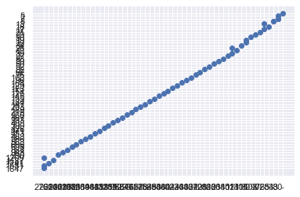

[output not shown]

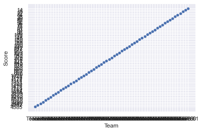

```python
plt.scatter(Sports.PlayedGames,Sports.WonGames)
plt.show()
Sports.plot.scatter(x="Team",y="Score")
plt.show()
```

The data set has multiple observation and its really hard for beginner to sort and visualize. Despite of being new to Python programming, I learnt a lot by working on this data set. I tried to analyze this data Using MS Excel. The results follows:

A. Best Performing Team = Team 1 B. Oldest Team = Team 1 C. Team with Highest Goals = Team 1 D. Lowest Performing Team = Team 60

Based on the Analysis and general observations, Company 'X' should Choose first 10 teams. Then, Fetch more data from these teams in several other parameters e.g. data of players who scored 3 pointers. It would be better to perform Video content Analysis of the past games. This would enable better decision making.

I think this Part 2 assignment requires no changes. It would be better if there are realisitic parameters related to Basketball game like eg : Adjusted Offensive Efficiency, Adjusted Defensive Efficiency, Power Rating and Effective Field Goal Percentage Shot.

# PART-3

```python
import pandas as pd
import matplotlib.pyplot as plt
import seaborn as sns
import numpy as np
from scipy.stats import norm
from sklearn.preprocessing import StandardScaler
from scipy import stats
import warnings
warnings.filterwarnings('ignore')
%matplotlib inline
```

# 1. Data Warehouse

```python
df_train = pd.read_csv('Startup.csv')
```

```python
df_train.head()
```

|  | Startup | Product | Funding | Event | Result | OperatingState |
| --- | --- | --- | --- | --- | --- | --- |
| 0 | 2600Hz | 2600hz.com | NaN | Disrupt SF 2013 | Contestant | Operating |
| 1 | 3DLT | 3dlt.com | $630K | Disrupt NYC 2013 | Contestant | Closed |
| 2 | 3DPrinterOS | 3dprinteros.com | NaN | Disrupt SF 2016 | Contestant | Operating |
| 3 | 3Dprintler | 3dprintler.com | $1M | Disrupt NY 2016 | Audience choice | Operating |
| 4 | 42 Technologies | 42technologies.com | NaN | Disrupt NYC 2013 | Contestant | Operating |

```python
df_train.head(8)
```

|  | Startup | Product | Funding | Event | Result | OperatingState |
| --- | --- | --- | --- | --- | --- | --- |
| 0 | 2600Hz | 2600hz.com | NaN | Disrupt SF 2013 | Contestant | Operating |
| 1 | 3DLT | 3dlt.com | $630K | Disrupt NYC 2013 | Contestant | Closed |
| 2 | 3DPrinterOS | 3dprinteros.com | NaN | Disrupt SF 2016 | Contestant | Operating |
| 3 | 3Dprintler | 3dprintler.com | $1M | Disrupt NY 2016 | Audience choice | Operating |
| 4 | 42 Technologies | 42technologies.com | NaN | Disrupt NYC 2013 | Contestant | Operating |
| 5 | 5to1 | 5to1.com | $19.3M | TC50 2009 | Contestant | Acquired |
| 6 | 8 Securities | 8securities.com | $29M | Disrupt Beijing 2011 | Finalist | Operating |
| 7 | 8020 Media | 8020media.com | NaN | TC40 2007 | Contestant | Operating |

```python
df_train.tail(10)
```

|  | Startup | Product | Funding | Event | Result | OperatingState |
| --- | --- | --- | --- | --- | --- | --- |
| 652 | Yuwan | iyuwan.cn | NaN | Disrupt Beijing 2011 | Contestant | Closed |
| 653 | ZAP! | zapreklam.com/ | NaN | Disrupt EU 2014 | Audience choice | Operating |
| 654 | ZEFR | zefr.com | $62.1M | Disrupt NYC 2010 | Contestant | Operating |
| 655 | Zello | zello.com | NaN | TC40 2007 | Contestant | Operating |
| 656 | Zenefits | zenefits.com | $583.6M | Disrupt NYC 2013 | Finalist | Operating |
| 657 | Zivity | zivity.com | $8M | TC40 2007 | Contestant | Operating |
| 658 | Zmorph | zmorph3d.com | $1M | - | Audience choice | Operating |
| 659 | Zocdoc | zocdoc.com | $223M | TC40 2007 | Contestant | Operating |
| 660 | Zula | zulaapp.com | $3.4M | Disrupt SF 2013 | Audience choice | Operating |
| 661 | Zumper | zumper.com | $31.5M | Disrupt SF 2012 | Finalist | Operating |

```python
print(df_train.shape)
print (df_train.size)
```

```
(662, 6)
3972
```

```python
df_train.info()
```

```
<class 'pandas.core.frame.DataFrame'>
RangeIndex: 662 entries, 0 to 661
Data columns (total 6 columns):
 #   Column          Non-Null Count  Dtype
---  ------          --------------  -----
 0   Startup         662 non-null    object
 1   Product         656 non-null    object
 2   Funding         448 non-null    object
 3   Event           662 non-null    object
 4   Result          662 non-null    object
 5   OperatingState  662 non-null    object
dtypes: object(6)
memory usage: 31.2+ KB
```

```python
df_train.count()
```

```
Startup           662
Product           656
Funding           448
Event             662
Result            662
OperatingState    662
dtype: int64
```

# 2. Data exploration

```python
df_train.isnull().sum()
```

```
Startup             0
Product             6
Funding           214
Event               0
Result              0
OperatingState      0
dtype: int64
```

```python
df_train.isnull().any().any()
```

```
True
```

```python
df_train.isnull().any()
```

```
Startup           False
Product            True
Funding            True
Event             False
Result            False
OperatingState    False
dtype: bool
```

```python
null_cols = df_train.columns[df_train.isnull().any()]
null_cols = list(null_cols)
```

```python
df_train.isnull().sum()
```

```
Startup             0
Product             6
Funding           214
Event               0
Result              0
OperatingState      0
dtype: int64
```

```python
df_train[df_train['Funding'].isnull()]
```

|  | Startup | Product | Funding | Event | Result | OperatingState |
| --- | --- | --- | --- | --- | --- | --- |
| 0 | 2600Hz | 2600hz.com | NaN | Disrupt SF 2013 | Contestant | Operating |
| 2 | 3DPrinterOS | 3dprinteros.com | NaN | Disrupt SF 2016 | Contestant | Operating |
| 4 | 42 Technologies | 42technologies.com | NaN | Disrupt NYC 2013 | Contestant | Operating |
| 7 | 8020 Media | 8020media.com | NaN | TC40 2007 | Contestant | Operating |
| 8 | About Last Night | aboutlastnight.net | NaN | Disrupt NYC 2012 | Contestant | Operating |
| ... | ... | ... | ... | ... | ... | ... |
| 648 | YOOBIC | yoobic.com | NaN | Disrupt London 2015 | Finalist | Operating |
| 651 | YourVersion | yourversion.com | NaN | TC50 2009 | Audience choice | Operating |
| 652 | Yuwan | iyuwan.cn | NaN | Disrupt Beijing 2011 | Contestant | Closed |
| 653 | ZAP! | zapreklam.com/ | NaN | Disrupt EU 2014 | Audience choice | Operating |
| 655 | Zello | zello.com | NaN | TC40 2007 | Contestant | Operating |

214 rows × 6 columns

```python
df_train['Funding'].count()
```

```
448
```

# 3. Data preprocessing & visualisation

```python
df_train[df_train.Funding.isnull()]
df_train[~df_train.Funding.isnull()]
```

|  | Startup | Product | Funding | Event | Result | OperatingState |
| --- | --- | --- | --- | --- | --- | --- |
| 1 | 3DLT | 3dlt.com | $630K | Disrupt NYC 2013 | Contestant | Closed |
| 3 | 3Dprintler | 3dprintler.com | $1M | Disrupt NY 2016 | Audience choice | Operating |
| 5 | 5to1 | 5to1.com | $19.3M | TC50 2009 | Contestant | Acquired |
| 6 | 8 Securities | 8securities.com | $29M | Disrupt Beijing 2011 | Finalist | Operating |
| 10 | AdhereTech | adheretech.com | $1.8M | Hardware Battlefield 2014 | Contestant | Operating |
| ... | ... | ... | ... | ... | ... | ... |
| 657 | Zivity | zivity.com | $8M | TC40 2007 | Contestant | Operating |
| 658 | Zmorph | zmorph3d.com | $1M | - | Audience choice | Operating |
| 659 | Zocdoc | zocdoc.com | $223M | TC40 2007 | Contestant | Operating |
| 660 | Zula | zulaapp.com | $3.4M | Disrupt SF 2013 | Audience choice | Operating |
| 661 | Zumper | zumper.com | $31.5M | Disrupt SF 2012 | Finalist | Operating |

448 rows × 6 columns

```python
df_train_dropped = df_train.dropna()
df_train_dropped.shape
```

```
(446, 6)
```

```python
df_train['FUNDING']= pd.factorize(df_train.Funding)[0]
```

```python
df_train.Funding.value_counts()
```

```
$1M      17
$2M      12
$3M       9
$1.2M     9
$1.3M     9
         ..
$746K     1
$4.3M     1
$4.7M     1
$72M      1
$863K     1
Name: Funding, Length: 240, dtype: int64
```

```python
df_train.describe(include="all")
```

|  | Startup | Product | Funding | Event | Result | OperatingState | FUNDING |
| --- | --- | --- | --- | --- | --- | --- | --- |
| count | 662 | 656 | 448 | 662 | 662 | 662 | 662.000000 |
| unique | 662 | 656 | 240 | 26 | 5 | 4 | NaN |
| top | Ritual | tailorbrands.com | $1M | TC50 2008 | Contestant | Operating | NaN |
| freq | 1 | 1 | 17 | 52 | 488 | 465 | NaN |
| mean | NaN | NaN | NaN | NaN | NaN | NaN | 64.362538 |
| std | NaN | NaN | NaN | NaN | NaN | NaN | 71.454258 |
| min | NaN | NaN | NaN | NaN | NaN | NaN | -1.000000 |
| 25% | NaN | NaN | NaN | NaN | NaN | NaN | -1.000000 |
| 50% | NaN | NaN | NaN | NaN | NaN | NaN | 39.000000 |
| 75% | NaN | NaN | NaN | NaN | NaN | NaN | 115.000000 |
| max | NaN | NaN | NaN | NaN | NaN | NaN | 239.000000 |

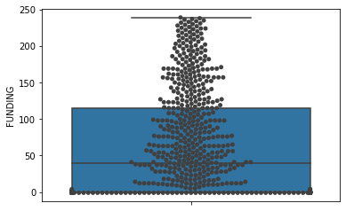

```python
import seaborn as sns
sns.boxplot(y="FUNDING", data=df_train)
sns.swarmplot(y="FUNDING", data=df_train, color=".25")
```

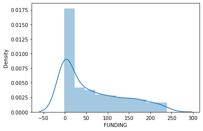

```python
sns.distplot(df_train['FUNDING'])
```

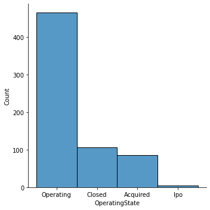

```python
sns.displot(data=df_train, x="OperatingState")
```

# 4.Statistical analysis

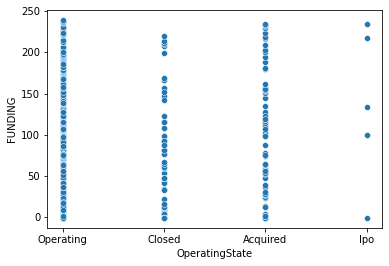

```python
sns.scatterplot(data=df_train, y="FUNDING", x="OperatingState")
```

```python
import numpy as np
import pandas as pd
from scipy.stats import f
import matplotlib.pyplot as plt
Operating = df_train[df['OperatingState'] == 'Operating'].Funding.value_counts()[1]
Closed = df_train[df['OperatingState'] == 'Closed'].Funding.value_counts()[1]
n_Operating = df_train.OperatingState.value_counts()[1]
n_Closed = df_train.OperatingState.value_counts()[0]
print([Operating, Closed], [n_Operating, n_Closed])
print(f' Proportion of funding in operating and closed state = {round(11/106,2)}%, {round(3/465,2)}% respectively')
```

```
[11, 3] [106, 465]
 Proportion of funding in operating and closed state = 0.1%, 0.01% respectively
```

Fail to Reject H0 = There is no significant difference between Funds raised by companies that are still operating vs companies that closed down. Reject H0 = There is significant difference between Funds raised by companies that are still operating vs companies that closed down.

```python
from statsmodels.stats.proportion import proportions_ztest
stat, pval = proportions_ztest([Operating, Closed] , [n_Operating, n_Closed])

if pval < 0.05:
    print(f'With a p-value of {round(pval,4)} the difference is significant. aka |We reject the null|')
else:
    print(f'With a p-value of {round(pval,4)} the difference is not significant. aka |We fail to reject the null|')
```

```
With a p-value of 0.0 the difference is significant. aka |We reject the null|
```

```python
shallow_copy = df_train.copy(deep=False)
```

```python
df_train['Result'].value_counts()
```

```
Contestant         488
Finalist            84
Audience choice     41
Winner              26
Runner up           23
Name: Result, dtype: int64
```

```python
Operating_Win_Cont = df_train[df['OperatingState']== Operating]
Operating_Win_Cont.Result.value_counts()
```

```
Series([], Name: Result, dtype: int64)
```

```python
##Calculate percentage of winners that are still operating and percentage of contestants that are still operating
```

```python
df_train.groupby('Result')['OperatingState'].value_counts()
```

```
Result           OperatingState
Audience choice  Operating          32
                 Closed              9
Contestant       Operating         332
                 Closed             90
                 Acquired           62
                 Ipo                 4
Finalist         Operating          61
                 Acquired           15
                 Closed              7
                 Ipo                 1
Runner up        Operating          21
                 Acquired            2
Winner           Operating          19
                 Acquired            7
Name: OperatingState, dtype: int64
```

```python
Winner = df_train[df['Result'] == 'Winner'].OperatingState.value_counts()[0]
Contestant = df_train[df['Result'] == 'Contestant'].OperatingState.value_counts()[0]
print([Winner, Contestant])
print(f' Proportion of winners that are still operating to contestants that are still operating = {round(19/332,2)}% respectively')
```

```
[19, 332]
 Proportion of winners that are still operating to contestants that are still operating = 0.06% respectively
```

```python
v1, v2 = np.var(Winner) , np.var(Contestant)
print(v1,v2)
```

```
0.0 0.0
```

```python
Ho : Proportion of winners that are still operating to contestants that are still operating is same
Ha : Contestants operating startup are more compared to winners
```

```python
n = 332
dof = n - 1
alpha = 0.05
chi_critical = 420.415
chi = (dof*v1)/v2
if chi < chi_critical:
    print("Proportion of winners that are still operating to contestants that are still operating is same")
else:
    print("Since the test statistic is more than the critical value, Contestants operating startup are more compared to winners")
```

```
Since the test statistic is more than the critical value, Contestants operating startup are more compared to winners
```

```python
df_train['Event'].value_counts()
```

```
TC50 2008                    52
TC50 2009                    50
TC40 2007                    40
Disrupt NYC 2011             32
Disrupt SF 2011              31
Disrupt NYC 2013             31
Disrupt SF 2013              31
Disrupt SF 2012              30
Disrupt NYC 2012             30
Disrupt SF 2014              28
Disrupt SF 2015              27
Disrupt NYC 2014             27
Disrupt SF 2010              26
Disrupt NY 2015              26
Disrupt SF 2016              26
Disrupt NY 2016              22
Disrupt NYC 2010             22
Disrupt Beijing 2011         18
Disrupt EU 2013              15
Hardware Battlefield 2015    15
Disrupt EU 2014              15
Disrupt London 2015          15
Hardware Battlefield 2014    14
-                            13
Disrupt London 2016          13
Hardware Battlefield 2016    13
Name: Event, dtype: int64
```

```python
import pandas as pd
import matplotlib.pyplot as plt
import seaborn as sns
import numpy as np
from scipy.stats import norm
from sklearn.preprocessing import StandardScaler
from scipy import stats
import warnings
warnings.filterwarnings('ignore')
%matplotlib inline
df_train = pd.read_csv('Startup.csv')
df_train.dropna(inplace = True)
new = df_train["Event"].str.split(" ", n = 1, expand = True)
df_train["KY"]= new[0]
df_train["Place"]= new[1]
df_train.drop(columns =["Event"], inplace = True)
df_train
```

|  | Startup | Product | Funding | Result | OperatingState | KY | Place |
| --- | --- | --- | --- | --- | --- | --- | --- |
| 1 | 3DLT | 3dlt.com | $630K | Contestant | Closed | Disrupt | NYC 2013 |
| 3 | 3Dprintler | 3dprintler.com | $1M | Audience choice | Operating | Disrupt | NY 2016 |
| 5 | 5to1 | 5to1.com | $19.3M | Contestant | Acquired | TC50 | 2009 |
| 6 | 8 Securities | 8securities.com | $29M | Finalist | Operating | Disrupt | Beijing 2011 |
| 10 | AdhereTech | adheretech.com | $1.8M | Contestant | Operating | Hardware | Battlefield 2014 |
| ... | ... | ... | ... | ... | ... | ... | ... |
| 657 | Zivity | zivity.com | $8M | Contestant | Operating | TC40 | 2007 |
| 658 | Zmorph | zmorph3d.com | $1M | Audience choice | Operating | - | None |
| 659 | Zocdoc | zocdoc.com | $223M | Contestant | Operating | TC40 | 2007 |
| 660 | Zula | zulaapp.com | $3.4M | Audience choice | Operating | Disrupt | SF 2013 |
| 661 | Zumper | zumper.com | $31.5M | Finalist | Operating | Disrupt | SF 2012 |

446 rows × 7 columns

```python
new = df_train["Place"].str.split(" ", n = 1, expand = True)
df_train["City"]= new[0]
df_train["Year"]= new[1]
df_train.drop(columns =["Place"], inplace = True)
df_train
```

|  | Startup | Product | Funding | Result | OperatingState | KY | City | Year |
| --- | --- | --- | --- | --- | --- | --- | --- | --- |
| 1 | 3DLT | 3dlt.com | $630K | Contestant | Closed | Disrupt | NYC | 2013 |
| 3 | 3Dprintler | 3dprintler.com | $1M | Audience choice | Operating | Disrupt | NY | 2016 |
| 5 | 5to1 | 5to1.com | $19.3M | Contestant | Acquired | TC50 | 2009 | None |
| 6 | 8 Securities | 8securities.com | $29M | Finalist | Operating | Disrupt | Beijing | 2011 |
| 10 | AdhereTech | adheretech.com | $1.8M | Contestant | Operating | Hardware | Battlefield | 2014 |
| ... | ... | ... | ... | ... | ... | ... | ... | ... |
| 657 | Zivity | zivity.com | $8M | Contestant | Operating | TC40 | 2007 | None |
| 658 | Zmorph | zmorph3d.com | $1M | Audience choice | Operating | - | None | None |
| 659 | Zocdoc | zocdoc.com | $223M | Contestant | Operating | TC40 | 2007 | None |
| 660 | Zula | zulaapp.com | $3.4M | Audience choice | Operating | Disrupt | SF | 2013 |
| 661 | Zumper | zumper.com | $31.5M | Finalist | Operating | Disrupt | SF | 2012 |

446 rows × 8 columns

```python
three_cities = ['NY','SF','EU']
C=df_train[df_train.City.isin(three_cities)]
np.asarray(C)
```

```
array([['3Dprintler', '3dprintler.com', '$1M', ..., 'Disrupt', 'NY',
        '2016'],
       ['Agrilyst', 'agrilyst.com', '$1M', ..., 'Disrupt', 'SF', '2015'],
       ['Aircall', 'aircall.io', '$11.6M', ..., 'Disrupt', 'SF', '2015'],
       ...,
       ['YourMechanic', 'yourmechanic.com', '$28M', ..., 'Disrupt', 'SF',
        '2012'],
       ['Zula', 'zulaapp.com', '$3.4M', ..., 'Disrupt', 'SF', '2013'],
       ['Zumper', 'zumper.com', '$31.5M', ..., 'Disrupt', 'SF', '2012']],
      dtype=object)
```

5.The 'event' data coloumn was difficult to solve. To make it ease seperate them as Event place and Event date. Apart from that some questions were not on the study module. Its more generalized and difficult for first time programmers.